# week8

# Question 11.1

Using the crime data set uscrime.txt from Questions 8.2, 9.1, and 10.1, build a regression model using:

1. Stepwise regression
2. Lasso
3. Elastic net

For Parts 2 and 3, remember to scale the data first – otherwise, the regression coefficients will be on different scales and the constraint won’t have the desired effect. For Parts 2 and 3, use the glmnet function in R.

Notes on R:

- For the elastic net model, what we called λ in the videos, glmnet calls “alpha”; you can get a range of results by varying alpha from 1 (lasso) to 0 (ridge regression) [and, of course, other values of alpha in between].
- In a function call like glmnet(x,y,family=”mgaussian”,alpha=1) the predictors x need to be in R’s matrix format, rather than data frame format. You can convert a data frame to a matrix using as.matrix – for example, x <- as.matrix(data[,1:n-1])
- Rather than specifying a value of T, glmnet returns models for a variety of values of T.

## Stepwise regression

```r
library(caret)
crime_data=read.table("http://www.statsci.org/data/general/uscrime.txt", header = TRUE)
predictors<-c(colnames(crime_data))
predictors<-predictors[-16]

set.seed(290)
ind<-sample(2,nrow(crime_data), replace=TRUE, prob=c(0.8,0.2))
training<- crime_data[ind==1,]
testing<- crime_data[ind==2,]


num_of_predict<-length(predictors)

models<-list()
factors<-c()

printf <- function(...)print(sprintf(...))
```

Stepwise regression - Manual Method

Function to calculate the AIC for each combination of predictors

```r
#function to calculate AIC
calculate_aic<-function(predictors,primaryFormula) {
  aic_table<-NULL
  num_of_predict<-length(predictors)
  for (i in 1:num_of_predict) {
    formula<-as.formula(paste(primaryFormula, predictors[i], sep="+"))

    #get the aic and the predictor value after training a regression model
    aic_table<-rbind.data.frame(aic_table,data.frame("aic"=(glm(formula, data=training ))$aic,"predictor"=predictors[i]))

}

  return (aic_table)
}
```

- Step 1: Regress each predictor on “Crime” separately, i.e. Crime ~ Po1, Crime ~ M, Crime ~ Ed etc and calculate teh AIC values returned. Pick the predictor with the lowest AIC value to start the step progression
- Step 2: After selecting the best predictor from step 1 above, keep that predictor as constant in the model formula and add other predictors one by one. Repeat Step 1. ex: of Po1 was the predictor returned as the best predictor with low AIC from Step1, set the formula as “Crime ~ Po1” and fit a regressor for different predictors with Po1 being constant, i.e. Crime ~ Po1 + M , Crime ~ Po1 + Ed, Crime ~ Po1 + So etc …
- Step 3: Repeat Step 1 and 2 and in each iteration select the best predictor that lowers the AIC value. If the AIC value stops improving break.
- Step 4: fit a model with teh final set of predictors as provided by the iteration of Step 1 to Step 3

```r
# Step1: Calculate the aic-values for each of the variables independently
primaryFormula<-"Crime ~ "
aic_table<-calculate_aic(predictors,primaryFormula)
aic_table
```

```
##         aic predictor
## 1  537.6721         M
## 2  538.5261        So
## 3  534.8854        Ed
## 4  506.2006       Po1
## 5  510.0365       Po2
## 6  536.3219        LF
## 7  535.9376       M.F
## 8  529.1513       Pop
## 9  538.5833        NW
## 10 538.3835        U1
## 11 537.7772        U2
## 12 529.8785    Wealth
## 13 537.7280      Ineq
## 14 532.7419      Prob
## 15 538.4514      Time
```

```r
# Select the best predictor with lowest AIC value to start the stepwise regression
library(tidyverse)
bestAIC<-min(aic_table$aic)
pred_min<- filter(aic_table,aic==min(aic_table$aic))$predictor
pred_min
```

```
## [1] Po1
## Levels: M So Ed Po1 Po2 LF M.F Pop NW U1 U2 Wealth Ineq Prob Time
```

```r
primaryFormula<-paste("Crime ~ ",pred_min)

primaryFormula
```

```
## [1] "Crime ~  Po1"
```

```r
# remove the chosen predictor from the list
predictors<-predictors[-match(pred_min,predictors) ]
predictors
```

```
##  [1] "M"      "So"     "Ed"     "Po2"    "LF"     "M.F"    "Pop"    "NW"
##  [9] "U1"     "U2"     "Wealth" "Ineq"   "Prob"   "Time"
```

```r
#Step 2

while(1) {

  aic_table<-calculate_aic(predictors,primaryFormula)
  print(aic_table)
  aicmin<-min(aic_table$aic)


  if(aicmin <= bestAIC) {
    bestAIC=aicmin
    print(bestAIC)
    pred_min<- filter(aic_table,aic==bestAIC)$predictor
    primaryFormula<-paste(primaryFormula,pred_min, sep = "+")
    print(primaryFormula)
    predictors<-predictors[-match(pred_min,predictors) ]

  }else {
    printf("Final Model formula %s", primaryFormula)
    break
  }


}
```

```
##         aic predictor
## 1  502.6400         M
## 2  505.3805        So
## 3  507.2837        Ed
## 4  503.8704       Po2
## 5  507.5545        LF
## 6  506.4820       M.F
## 7  506.0765       Pop
## 8  504.5893        NW
## 9  508.1700        U1
## 10 507.9599        U2
## 11 503.8331    Wealth
## 12 494.1755      Ineq
## 13 507.6061      Prob
## 14 507.3786      Time
```

[output cut: 59 more lines]

```r
#Train final model
final_model<-glm(as.formula(primaryFormula),data=crime_data)
summary(final_model)
```

```
##
## Call:
## glm(formula = as.formula(primaryFormula), data = crime_data)
##
## Deviance Residuals:
##     Min       1Q   Median       3Q      Max
## -530.29  -133.96    12.33   145.69   448.14
##
## Coefficients:
##             Estimate Std. Error t value Pr(>|t|)
## (Intercept) -4607.33    1182.01  -3.898 0.000352 ***
## Po1           118.08      14.45   8.173 3.84e-10 ***
## Ineq           74.42      14.63   5.085 8.52e-06 ***
## Ed            109.56      51.51   2.127 0.039483 *
## Prob        -3800.54    1653.20  -2.299 0.026680 *
## M.F            21.23      12.72   1.669 0.102782
## ---
## Signif. codes:  0 '***' 0.001 '**' 0.01 '*' 0.05 '.' 0.1 ' ' 1
##
## (Dispersion parameter for gaussian family taken to be 47180.2)
##
##     Null deviance: 6880928  on 46  degrees of freedom
## Residual deviance: 1934388  on 41  degrees of freedom
## AIC: 646.76
##
## Number of Fisher Scoring iterations: 2
```

```r
#RMSE
library(ModelMetrics)
p<-predict(final_model, testing[,-16])
rmse(testing$Crime,p)
```

```
## [1] 277.2467
```

## Stepwise regression using the inbuild Step function

```r
null_model <- glm(Crime ~ 1, data = crime_data)

# Specify the full model using all of the potential predictors
full_model <- glm(Crime ~ ., data = crime_data)

# Use a forward stepwise algorithm to build the optimal model
step_model <- step(null_model, scope = list(lower = null_model, upper = full_model), direction = "forward")
```

```
## Start:  AIC=696.4
## Crime ~ 1
##
##          Df Deviance    AIC
## + Po1     1  3627626 668.32
## + Po2     1  3822302 670.77
## + Wealth  1  5540775 688.22
## + Prob    1  5623853 688.92
## + Pop     1  6097267 692.72
## + Ed      1  6163781 693.23
## + M.F     1  6566061 696.20
## <none>       6880928 696.40
## + LF      1  6635482 696.70
## + Ineq    1  6660397 696.87
## + U2      1  6664573 696.90
## + Time    1  6726383 697.34
## + So      1  6824400 698.02
## + M       1  6825844 698.03
## + U1      1  6863395 698.28
## + NW      1  6873615 698.35
##
## Step:  AIC=668.32
## Crime ~ Po1
##
##          Df Deviance    AIC
## + Ineq    1  2887807 659.60
## + M       1  3010885 661.56
## + M.F     1  3377104 666.95
## + NW      1  3395192 667.20
## + So      1  3408528 667.39
## + Wealth  1  3446754 667.91
## <none>       3627626 668.32
## + Po2     1  3481459 668.38
## + Prob    1  3535348 669.10
## + LF      1  3550147 669.30
## + Time    1  3584441 669.75
## + U2      1  3609778 670.08
## + Pop     1  3621959 670.24
## + U1      1  3624748 670.28
## + Ed      1  3626859 670.31
```

[output cut: 70 more lines]

```
##
## Step:  AIC=640.17
## Crime ~ Po1 + Ineq + Ed + M + Prob + U2
##
##          Df Deviance    AIC
## <none>       1611057 640.17
## + Wealth  1  1551147 640.39
## + U1      1  1556227 640.54
## + Pop     1  1559737 640.64
## + M.F     1  1580112 641.25
## + Po2     1  1586040 641.43
## + So      1  1593098 641.64
## + LF      1  1597878 641.78
## + Time    1  1603898 641.96
## + NW      1  1610698 642.16
```

```r
# Summary
summary(step_model)
```

```
##
## Call:
## glm(formula = Crime ~ Po1 + Ineq + Ed + M + Prob + U2, data = crime_data)
##
## Deviance Residuals:
##     Min       1Q   Median       3Q      Max
## -470.68   -78.41   -19.68   133.12   556.23
##
## Coefficients:
##             Estimate Std. Error t value Pr(>|t|)
## (Intercept) -5040.50     899.84  -5.602 1.72e-06 ***
## Po1           115.02      13.75   8.363 2.56e-10 ***
## Ineq           67.65      13.94   4.855 1.88e-05 ***
## Ed            196.47      44.75   4.390 8.07e-05 ***
## M             105.02      33.30   3.154  0.00305 **
## Prob        -3801.84    1528.10  -2.488  0.01711 *
## U2             89.37      40.91   2.185  0.03483 *
## ---
## Signif. codes:  0 '***' 0.001 '**' 0.01 '*' 0.05 '.' 0.1 ' ' 1
##
## (Dispersion parameter for gaussian family taken to be 40276.42)
##
##     Null deviance: 6880928  on 46  degrees of freedom
## Residual deviance: 1611057  on 40  degrees of freedom
## AIC: 640.17
##
## Number of Fisher Scoring iterations: 2
```

```r
p<-predict(step_model, testing[,-16])
rmse(testing$Crime,p)
```

```
## [1] 195.153
```

##LASSO and RIDGE

Scale data to be used for glmnet

```r
train.scaled = scale(training)

test.scaled = scale(testing)
summary(train.scaled)
```

```
##        M                 So                Ed               Po1
##  Min.   :-1.4642   Min.   :-0.7866   Min.   :-1.5217   Min.   :-1.2654
##  1st Qu.:-0.6913   1st Qu.:-0.7866   1st Qu.:-1.0617   1st Qu.:-0.7322
##  Median :-0.2752   Median :-0.7866   Median : 0.2765   Median :-0.2340
##  Mean   : 0.0000   Mean   : 0.0000   Mean   : 0.0000   Mean   : 0.0000
##  3rd Qu.: 0.4976   3rd Qu.: 1.2360   3rd Qu.: 0.9037   3rd Qu.: 0.3515
##  Max.   : 2.9746   Max.   : 1.2360   Max.   : 1.4055   Max.   : 2.7551
##       Po2                LF               M.F               Pop
##  Min.   :-1.3203   Min.   :-1.8157   Min.   :-1.6128   Min.   :-0.8991
##  1st Qu.:-0.7681   1st Qu.:-0.7830   1st Qu.:-0.5887   1st Qu.:-0.7011
##  Median :-0.2342   Median :-0.3436   Median :-0.2742   Median :-0.2095
##  Mean   : 0.0000   Mean   : 0.0000   Mean   : 0.0000   Mean   : 0.0000
##  3rd Qu.: 0.4101   3rd Qu.: 0.8090   3rd Qu.: 0.3387   3rd Qu.: 0.2087
##  Max.   : 2.4351   Max.   : 1.8588   Max.   : 2.8062   Max.   : 3.6202
##        NW                U1                U2               Wealth
##  Min.   :-0.9585   Min.   :-1.3609   Min.   :-1.80245   Min.   :-2.27356
##  1st Qu.:-0.7630   1st Qu.:-0.8473   1st Qu.:-0.77857   1st Qu.:-0.60905
##  Median :-0.3037   Median :-0.1493   Median :-0.01067   Median : 0.02009
##  Mean   : 0.0000   Mean   : 0.0000   Mean   : 0.00000   Mean   : 0.00000
##  3rd Qu.: 0.5354   3rd Qu.: 0.6014   3rd Qu.: 0.66125   3rd Qu.: 0.70373
##  Max.   : 2.8706   Max.   : 2.4321   Max.   : 2.42104   Max.   : 1.69946
##       Ineq               Prob              Time              Crime
##  Min.   :-1.68287   Min.   :-1.3899   Min.   :-2.10291   Min.   :-1.3265
##  1st Qu.:-0.73625   1st Qu.:-0.6558   1st Qu.:-0.70623   1st Qu.:-0.5973
##  Median :-0.09923   Median :-0.2462   Median :-0.08677   Median :-0.1575
##  Mean   : 0.00000   Mean   : 0.0000   Mean   : 0.00000   Mean   : 0.0000
##  3rd Qu.: 0.79976   3rd Qu.: 0.4245   3rd Qu.: 0.56939   3rd Qu.: 0.2261
##  Max.   : 1.88926   Max.   : 2.9357   Max.   : 2.20795   Max.   : 2.7928
```

```r
x = as.matrix(train.scaled[,-16])
y_train = training$Crime

x_test = as.matrix(test.scaled[,-16])
y_test = testing$Crime
```

RIDGE

```r
library(glmnet)
lambdas <- seq(0,5, by=0.001)
set.seed(123)
cv_ridge = cv.glmnet(x, y_train, alpha = 0, family = 'gaussian', lambda = lambdas)
optimal_lambda <- cv_ridge$lambda.min

optimal_lambda
```

```
## [1] 5
```

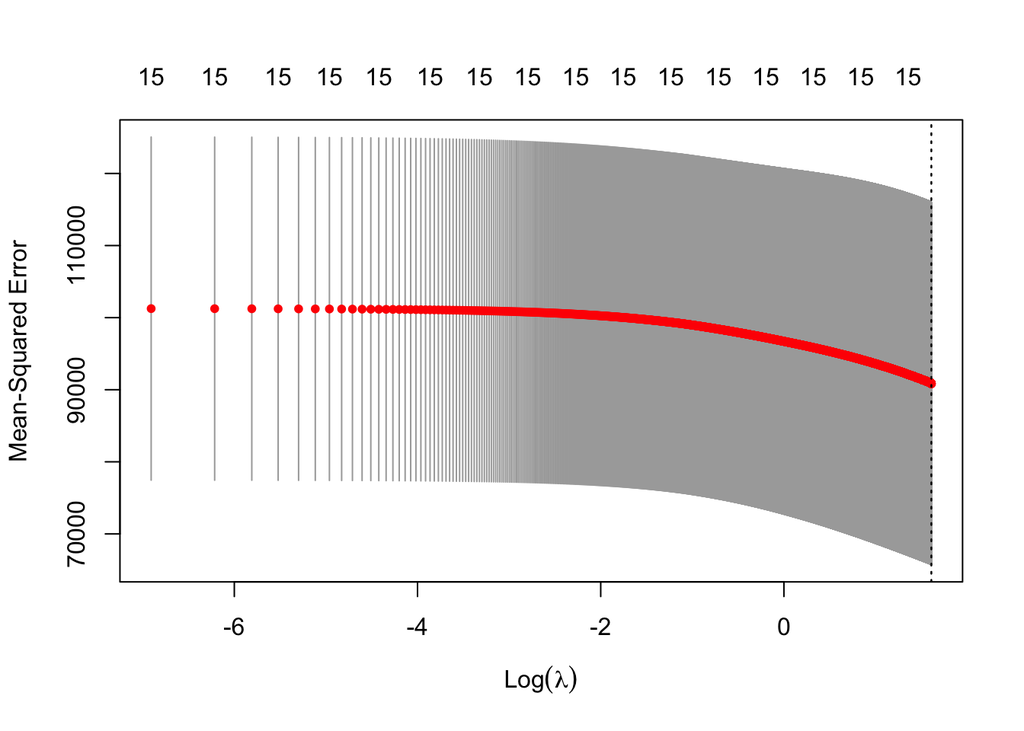

```r
plot(cv_ridge)
```

The lambda value of 5 seems to get the lowest MSE.

Clearly ridge does not make lot of coefficients zero.

```r
coef(cv_ridge,optimal_lambda )
```

```
## 16 x 1 sparse Matrix of class "dgCMatrix"
##                      1
## (Intercept) 873.638889
## M            27.475455
## So           -7.352236
## Ed          113.304133
## Po1         272.723217
## Po2         -15.263224
## LF           -3.364178
## M.F          90.816285
## Pop          68.711393
## NW           58.442705
## U1          -65.435994
## U2           54.845119
## Wealth       89.011955
## Ineq        259.828827
## Prob        -81.871873
## Time        -54.522673
```

Fit a model with optimal lambda values

```r
# Fit the final model on the training data
model_ridge_final <- glmnet(x,
                            y_train,
                            alpha = 0,
                            family = "gaussian",
                            lambda = optimal_lambda)
# Display regression coefficients
coef(model_ridge_final)
```

```
## 16 x 1 sparse Matrix of class "dgCMatrix"
##                     s0
## (Intercept) 873.638889
## M            27.475455
## So           -7.352236
## Ed          113.304133
## Po1         272.723217
## Po2         -15.263224
## LF           -3.364178
## M.F          90.816285
## Pop          68.711393
## NW           58.442705
## U1          -65.435994
## U2           54.845119
## Wealth       89.011955
## Ineq        259.828827
## Prob        -81.871873
## Time        -54.522673
```

```r
#RMSE

p<-predict(model_ridge_final, s=model_ridge_final$lambda.min, newx=x_test)
ridgermse<-rmse(testing$Crime,p)
printf("RMSE of Ridge regression %s",ridgermse)
```

```
## [1] "RMSE of Ridge regression 307.18170978514"
```

LASSO

```r
library(glmnet)

lambdas <- 10^seq(-2, 5, by = .001)

#LASSO
set.seed(123)
cv.lasso <- cv.glmnet(x, y_train, alpha = 1, family = 'gaussian')
optimal_lambda_lasso <- cv.lasso$lambda.min
optimal_lambda_lasso
```

```
## [1] 24.71158
```

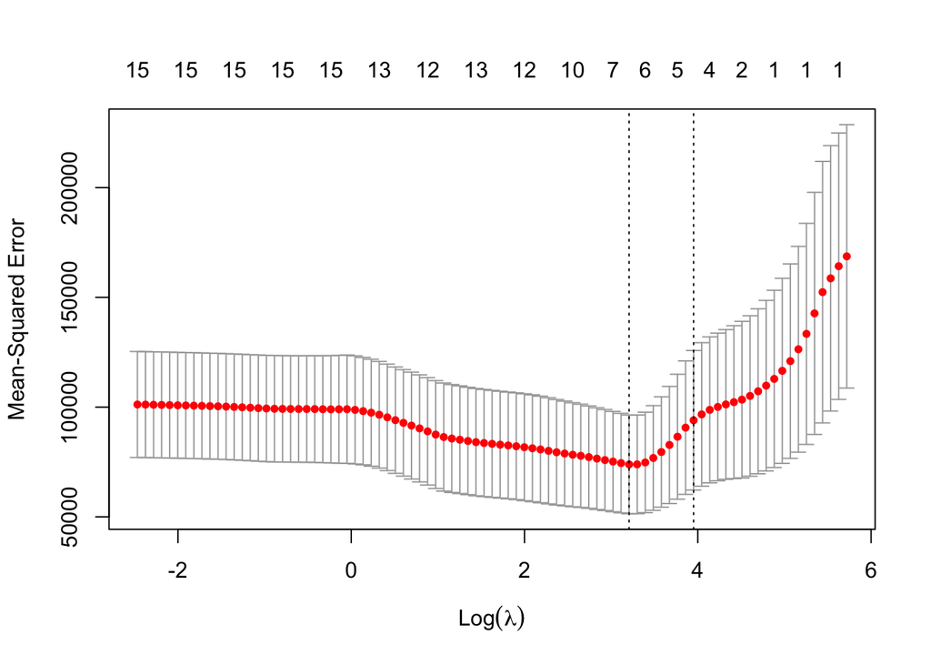

```r
plot(cv.lasso)
```

```r
coef(cv.lasso, cv.lasso$lambda.min)
```

```
## 16 x 1 sparse Matrix of class "dgCMatrix"
##                     1
## (Intercept) 873.63889
## M             .
## So            .
## Ed            .
## Po1         315.28610
## Po2           .
## LF           11.24803
## M.F          66.27617
## Pop          41.52015
## NW            .
## U1            .
## U2            .
## Wealth        .
## Ineq        128.50171
## Prob        -28.15916
## Time          .
```

Only Po1, LF,M.F, Pop, Ineq and Prob have a non zero coefficient.

```r
# Fit the final model on the training data
model_lasso_final <- glmnet(x,
                            y_train,
                            alpha = 1,
                            family = "gaussian",
                            lambda = cv.lasso$lambda.min)
# Display regression coefficients
coef(model_lasso_final)
```

```
## 16 x 1 sparse Matrix of class "dgCMatrix"
##                    s0
## (Intercept) 873.63889
## M             .
## So            .
## Ed            .
## Po1         315.42153
## Po2           .
## LF           11.26971
## M.F          66.21412
## Pop          41.41982
## NW            .
## U1            .
## U2            .
## Wealth        .
## Ineq        128.59464
## Prob        -28.18007
## Time          .
```

```r
#RMSE

p<-predict(model_lasso_final, s=model_lasso_final$lambda.min, newx=x_test)
p
```

```
##           s0
## 2  1046.7971
## 5   943.3458
## 9   629.5636
## 20 1003.0204
## 29 1439.9159
## 32  713.3289
## 33  657.4134
## 34  784.5396
## 36  829.0157
## 38  638.3496
## 46  924.7378
```

```r
lassormse<-rmse(testing$Crime,p)

printf("RMSE of Lasso regression %s",lassormse)
```

```
## [1] "RMSE of Lasso regression 337.96187148734"
```

We see that Ridge performs better than LASSO for the given dataset.